# Donor ID with cardelino

Davis McCarthy and Yuanhua Huang

EMBL-EBI, Hinxton, UK  
St Vincent's Institute of Medical Research, Melbourne, Australia

1 August 2018

#### Package

cardelino 0.0.9

# 1 Introduction

This document gives an introduction to and overview of inferring the **donor** identity of cells using the *cardelino* package. Many single-cell genomics studies can be enhanced by multiplexing donors, that is cells from multiple genetically distinct individuals (“donors”) are assayed together in a mixed population. Such experimental designs can be powerful for reducing cost of studies assaying cells from many donors and for enabling robustness to inevitable batch effects.

When cells from multiple donors are mixed together, the donor identity of each cell is unknown at the time of sequencing. However, natural genetic variation (specifically, single nucelotide polymorphisms) act as natural barcodes capturing the donor identity of each cell. Appropriate computational methods, such as presented here, can infer the donor identity for each cells and thus “demultiplex” a population of cells from multiple donors in preparation of the dataset for further downstream analysis.

*cardelino* contains general tools for inferring the clonal or donor identity of cells from single-cell transcriptomic data, focusing on RNA-seq data. Specifically, the package features:

- Methods to infer the **clonal identity** of single cells from scRNA-seq read information, given a clonal structure;
- Methods to infer the **donor identity** of single cells from scRNA-seq read information, when donor genotype data is available for a set of possible donors.

Here, we focus on demonstrating the use of `cardelino` to probabilistically assign cells to donors when donor genotypes are provided.

# 2 About the model

*cardelino* can use variant information extracted from single-cell RNA-seq reads to probabilistically assign single-cell transcriptomes to specific donor individuals.

Briefly, *cardelino* is based on a Bayesian mixture model with a beta-binomial error model to account for sequencing errors as well as a gene-specific model for allelic imbalance between haplotypes and associated bias in variant detection. Bayesian inference allows the model to account for uncertainty in model parameters and cell assignments.

We assume that donors are uniquely tagged by single nucleotide polymorphisms (SNPs), and that these mutations are known (e.g. chip genotyping or equivalent). Given a set of known SNPs, these sites can be interrogated in scRNA-seq reads to obtain evidence for the genotypes of each SNP in each cell. As input, the model requires the count of reads supporting the alternative allele at each variant site and the total number of reads overlapping the mutation site (“coverage”) in each cell, and the known genotypes of the donors at those SNPs (encoded as counts of the alternative allele, i.e. 0, 1, or 2).

Typically, coverage of SNPs in scRNA-seq data is very sparse (most SNPs in a given cell have no read coverage), but the *cardelino* model accounts for this sparsity and aggregates information across all available variant sites to infer donor identity. The model returns a posterior probability of assignment to each donor and also the probability that the “single cell” is in fact a “doublet” (two, or more, cells merged together in the assay).

# 3 Donor ID with donor genotypes provided

In many donor ID scenarios, reference genotype information will be available for each donor. That is, donors have been genotyped using a SNP chip platform, exome sequencing or similar, so we know the expected genotype of each SNP for each of the multiplexed donors from which our cells come.

To infer the donor identity of cells when a donor genotypes are provided, *cardelino* requires the following input data:

- **cell VCF file:** a variant call format (VCF) file from which we can extract the variant x cell matrices of integer counts of the number of reads supporting the alternative allele for each variant in each cell and the total number of reads overlapping each variant in each cell;
- **donor VCF file:** a VCF file containing genotypes for each of the multiplexed donors.

For compatibility with genomics pipelines, we accept variant data in VCF ([variant call format](https://github.com/samtools/hts-specs)) files. Both VCF files should be indexed.

As the `cardelino` model uses the read count data from the cell VCF file, it does not require “true genotyping” for the SNPs in the cells. We have had success using the `mpileup` and `call` methods in the [`bcftools`](http://www.htslib.org/doc/bcftools.html) software to generate cell VCF files. However, any appropriate method that produces a valid VCF and contains correct “AD” and “DP” fields in the VCF will work fine. Both VCF files are read into memory, so we recommend filtering large VCF files before applying `cardelino`. We suggest filtering the cell VCF file to just keep variants with read coverage in at least a small percentage of cells (say 3%) and then to filter both the cell and donor VCFs to contain just the variants that appear in both VCF files. Again, `bcftools` has good filtering methods for these purposes.

We load the package and look at an example donor ID dataset distributed with the package.

```r
library(cardelino)
cell_vcf <- read_vcf(system.file("extdata", "cells.donorid.vcf.gz",
                                 package = "cardelino"))
```

In this particular example, cells from three donors were mixed together. If we run probabilistic principal component analysis (PPCA) on the raw “genotypes” of the cells we can get a feel for the grouping of cells by donor.

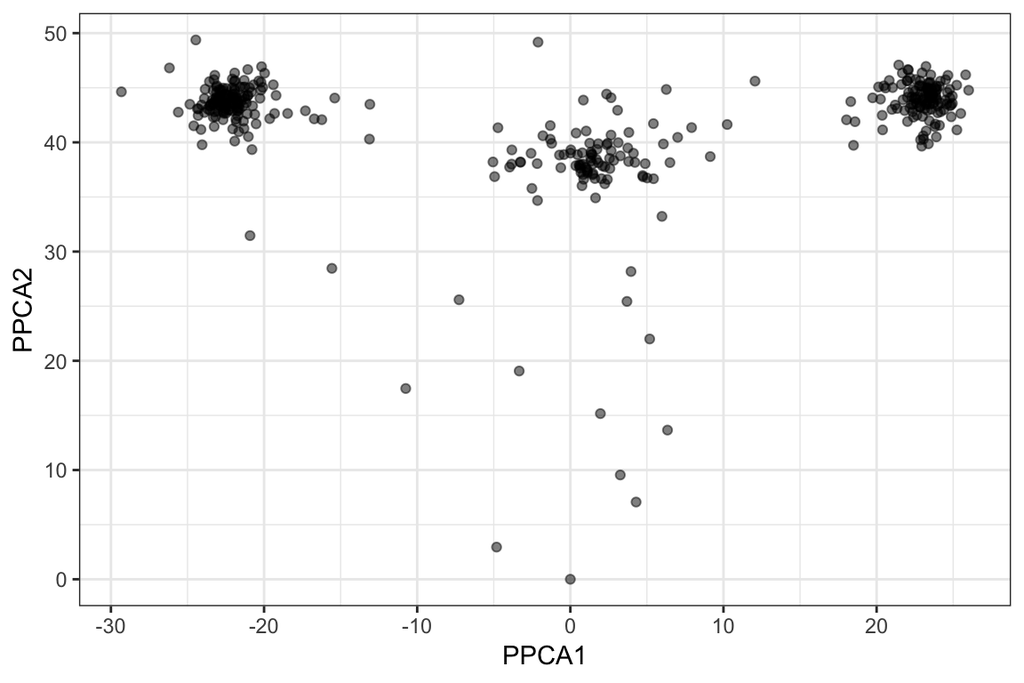

```r
raw_geno <-  VariantAnnotation::genotypeToSnpMatrix(
    VariantAnnotation::geno(cell_vcf, "GT"),
    ref = VariantAnnotation::ref(cell_vcf),
    alt = VariantAnnotation::alt(cell_vcf))
pp <- pcaMethods::ppca(as(raw_geno$genotypes, "numeric"))
df <- data.frame(PPCA1 <- pp@scores[, 1], PPCA2 <- pp@scores[, 2])
ggplot(df, aes(PPCA1, PPCA2)) +
        geom_point(alpha = 0.5) +
        theme_bw()
```

To infer donor identity, we use the `donor_id` function in *cardelino*. VCFs can be supplied either as file paths or as `CollapsedVCF` objects as produced when reading in data with the `read_vcf` function as above. Both usages are demonstrated below.

The example donor VCF file here contains genotype information for three donors that contributed cells to this multiplexed cell population. We utilise the option to detect doublets by setting `check_doublet = TRUE`. The `donor_id` function returns a list of outputs, one of which is the `assigned` data.frame with inferred donor ID (either a donor ID, “doublet” or “unassigned”).

```r
ids <- donor_id(cell_vcf,
                system.file("extdata", "donors.donorid.vcf.gz",
                                 package = "cardelino"),
                 check_doublet = TRUE)
```

```
## 2 random initializations is running.
## Total iterations: 11; logLik: -518783.41
## Total iterations: 11; logLik: -518783.41
```

```r
table(ids$assigned$donor_id)
```

```
##
##         doublet HPSI0114pf-joxm HPSI0414pf-gesg HPSI0614pf-ciwj
##               6             129             149              91
##      unassigned
##               9
```

The `assigned` data.frame contains the key information from the donor assignment, including the highest posterior probability value across the donors (`prob_max`), the posterior doublet probability (`prob_doublet`) and the number of variants with non-zero read coverage for the cell (`n_vars`). By default, if `n_vars` is less than 10, we expect that donor ID is unlikely to be accurate and return donor ID as “unassigned” for these cells. This threshold can be adjusted with the `n_vars_threshold` argument.

```r
head(ids$assigned)
```

```
##          cell        donor_id prob_max prob_doublet n_vars
## 1 22259_2#100 HPSI0614pf-ciwj        1    0.000e+00    850
## 2 22259_2#101 HPSI0114pf-joxm        1    0.000e+00    884
## 3 22259_2#102 HPSI0114pf-joxm        1    0.000e+00    901
## 4  22259_2#10 HPSI0414pf-gesg        1    0.000e+00    757
## 5 22259_2#103 HPSI0414pf-gesg        1   1.096e-287    431
## 6 22259_2#104 HPSI0614pf-ciwj        1   1.452e-118    125
```

We can see that doublets tend to be inferred for “cells” with fewer variants with coverage (that is for cells with less donor information). In this case, reassuringly, the inferred doublets include known “minibulk” wells (10 cells from multiple donors processed as one “cell”) and positive control wells (details not shown).

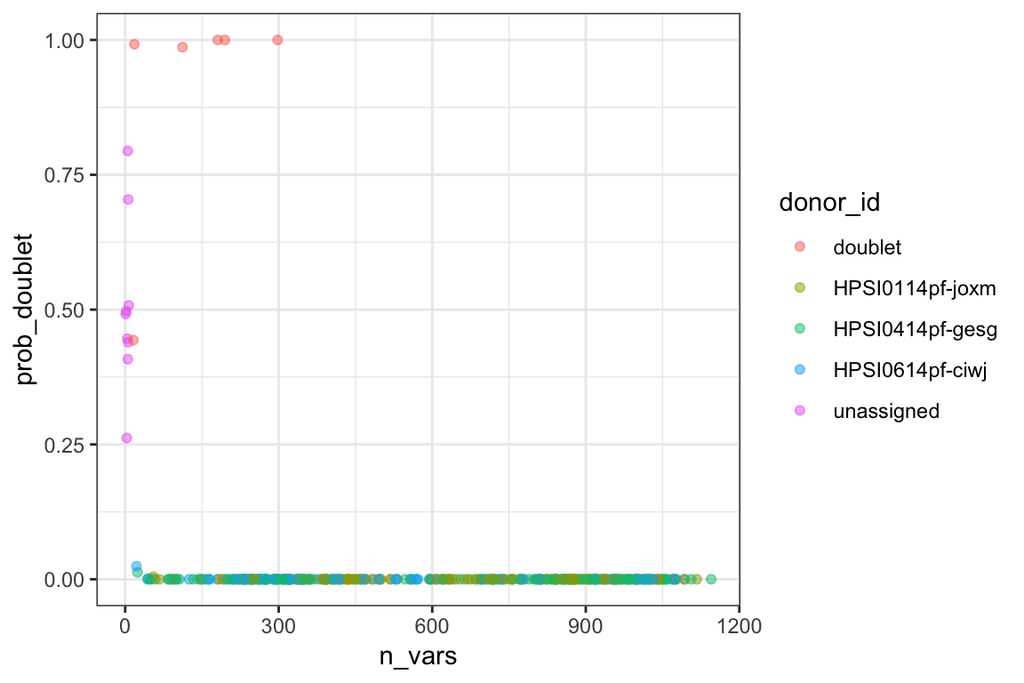

```r
ggplot(ids$assigned, aes(n_vars, prob_doublet, colour = donor_id)) +
    geom_point(alpha = 0.5) +
    theme_bw()
```

For most cells, the `cardelino` model is very confident about donor assignment (posterior probability of 1 for best-matching donor). Once there are more than about 30 variants with read coverage we can assign cells to donors with very high confidence.

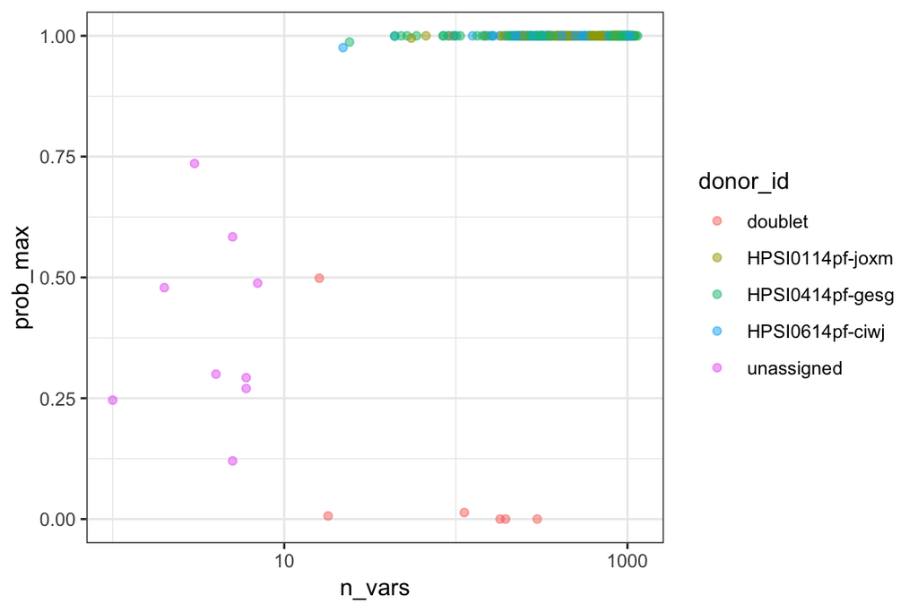

```r
ggplot(ids$assigned, aes(n_vars, prob_max, colour = donor_id)) +
    geom_point(alpha = 0.5) +
    scale_x_log10() +
    theme_bw()
```

When we map our donor ID back onto the PPCA plot we see that the clusters evident originally indeed correspond to the individual donors. Here, PPCA component 1 clearly separates the donors, while PPCA component 2 appears to reflect coverage of variants (unassigned cells with low coverage appear at low values in PPCA2).

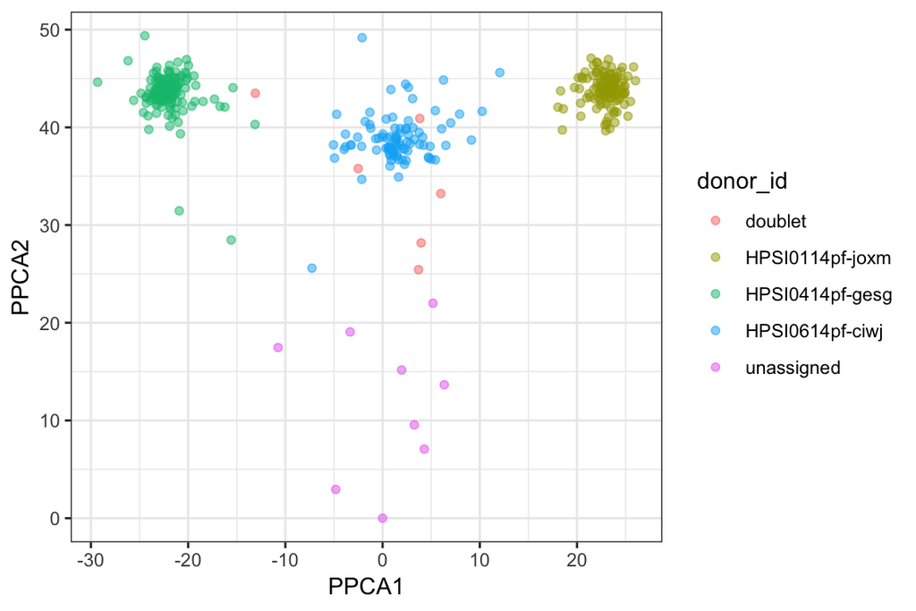

```r
df$donor_id <- ids$assigned$donor_id
ggplot(df, aes(PPCA1, PPCA2, colour = donor_id)) +
        geom_point(alpha = 0.5) +
        theme_bw()
```

With donor identity now inferred for these cells, the donor identities can be linked back to the expression profiles for the cells for downstream analysis.

# 4 Coping with “extreme” multiplexing

The high sensitivity and specifity of donor demultiplexing from scRNA-seq data enables the possibility of “extreme” multiplexing: studies assaying cells from hundreds of donors, with dozens of donors multiplexed per assay (say “per run”).

In such cases, it might be convenient to have a single donor reference genotype VCF file with hundreds of donor genotypes. The approach shown above will work when given a donor genotype VCF with hundreds of donors, but if only a subset of donors are multiplexed in a given run, then the default approach will be slow and likely call too many doublets (as we form doublet genotype profiles from all pairs of donor genotypes, so this scales as the square of the number of donors; with a large number of donors there is a *very* large number of possible doublet genotypes to choose from).

To handle these situations, we propose the following two-step approach:

- **First pass:** run `donor_id` with the full donor genotype VCF, without doublet detection;
- **Second pass:** run `donor_id` with doublet detection, but specifying the function to use just the donors that had at least once cell assigned in the first pass.

We demonstrate this approach on the same dataset as used above (although there are only three donors in this case, this same set of commands will work for hundreds of donors).

**First pass**: run without doublet detection.

```r
donor_vcf <- read_vcf(system.file("extdata", "donors.donorid.vcf.gz",
                                 package = "cardelino"))
ids_sing <- donor_id(cell_vcf, donor_vcf, check_doublet = FALSE)
```

```
## 2 random initializations is running.
## Total iterations: 11; logLik: -519929.32
## Total iterations: 11; logLik: -519929.32
```

**Second pass**: run with doublet detection, but just on the donors identified in the first pass.

```r
ids_doub <- donor_id(cell_vcf, donor_vcf, check_doublet = TRUE,
                        donors = unique(ids_sing$assigned$donor_id))
```

```
## 2 random initializations is running.
## Total iterations: 11; logLik: -518783.41
## Total iterations: 11; logLik: -518783.41
```

```r
table(ids_doub$assigned$donor_id)
```

```
##
##         doublet HPSI0114pf-joxm HPSI0414pf-gesg HPSI0614pf-ciwj
##               6             129             149              91
##      unassigned
##               9
```

In this case, the results are exactly the same as with the default approach demonstrated above (as they should be), but the flexibility of this approach for dealing with large numbers of donor genotypes should be clear.